# Classification of data from a particular news collection into categories such as international news and travel using machine learning and deep learning. Short description of the news dataset is used f

Running random forest classifier on valid dataset

```python
# rfcvalid = RandomForestClassifier()

# rfcv_model = rfcvalid.fit(x_train1, y_train1)

# rfcpredvalid = rfcv_model.predict(x_test1)

# print('Accuracy score :- {}'.format(round(accuracy_score(y_test1, rfcpredvalid), 2)))

# print(format(classification_report(y_test1, rfcpredvalid,zero_division=1)))
rfcv_model = RandomForestClassifier().fit(x_train1, y_train1)
mymodel = open('rtctrain1.sav', 'wb')
pickle.dump( rfcv_model, mymodel)
mymodel.close()
rfcpredvalid = rfcv_model.predict(x_test1)
```

```python
filename = 'rtctrain1.sav'
saved_clf = pickle.load(open(filename, 'rb'))
saved_clf.score(x_test1, y_test1)
```

```
0.8788819875776398
```

```python
print("---Test Set Results---")
print("Accuracy with logreg: {}".format(accuracy_score(y_test1, rfcpredvalid)))
print(classification_report(y_test1, rfcpredvalid))
```

```
---Test Set Results---
Accuracy with logreg: 0.8788819875776398
              precision    recall  f1-score   support

           0       0.91      0.54      0.68        76
           1       0.87      0.98      0.93       246

    accuracy                           0.88       322
   macro avg       0.89      0.76      0.80       322
weighted avg       0.88      0.88      0.87       322
```

Running Confusion matrix for error analysis on valid dataset for random forest classifier

```
True Positive(TP)  =  242
False Positive(FP) =  35
True Negative(TN)  =  41
False Negative(FN) =  4
Accuracy score :- 0.88
```

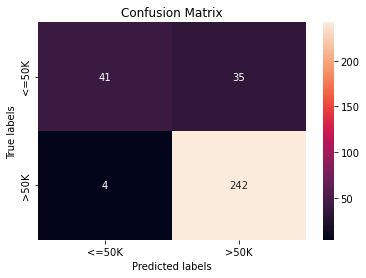

```python
cm=confusion_matrix(y_test1, rfcpredvalid) #you will need to change the latter to your desired output
cm


ax= plt.subplot()
sns.heatmap(cm, annot=True, fmt='g', ax=ax);  #Don't worry too much about the arguments here - we will return to this!

 #labels, title and ticks
ax.set_xlabel('Predicted labels');ax.set_ylabel('True labels');
ax.set_title('Confusion Matrix');
ax.xaxis.set_ticklabels(['<=50K', '>50K']); ax.yaxis.set_ticklabels(['<=50K','>50K' ]);
TN, FP, FN, TP = confusion_matrix(y_test1, rfcpredvalid).ravel()

print('True Positive(TP)  = ', TP)
print('False Positive(FP) = ', FP)
print('True Negative(TN)  = ', TN)
print('False Negative(FN) = ', FN)

print('Accuracy score :- {}'.format(round(accuracy_score(y_test1, rfcpredvalid), 2)))
```

Storing Predicted values into a dataframe

```python
rfcpredaav = pd.DataFrame(rfcpredvalid)
rfcpredaav.columns = ["RFC"]
rfcpredaav
```

|  | RFC |
| --- | --- |
| 0 | 1 |
| 1 | 0 |
| 2 | 1 |
| 3 | 1 |
| 4 | 1 |
| ... | ... |
| 317 | 1 |
| 318 | 1 |
| 319 | 1 |
| 320 | 1 |
| 321 | 0 |

322 rows × 1 columns

Printing Predicted values after using classifiers on valid dataset

```python
#https://softhints.com/display-two-pandas-dataframes-side-by-side-jupyter-notebook/
df3_styler = dtcvalidpred.style.set_table_attributes("style='display:inline'").set_caption('df3')
df4_styler = rfcpredaav.style.set_table_attributes("style='display:inline'").set_caption('df4')
display_html(df4_styler._repr_html_()+df3_styler._repr_html_(), raw=True)
```

df4

|  | RFC |
| --- | --- |
| 0 | 1 |
| 1 | 0 |
| 2 | 1 |
| 3 | 1 |
| 4 | 1 |
| 5 | 1 |
| 6 | 1 |
| 7 | 1 |
| 8 | 1 |
| 9 | 1 |
| 10 | 1 |
| 11 | 1 |
| 12 | 1 |
| 13 | 1 |
| 14 | 1 |
| 15 | 1 |
| 16 | 1 |
| 17 | 1 |
| 18 | 1 |
| 19 | 0 |
| 20 | 0 |
| 21 | 1 |
| 22 | 1 |
| 23 | 0 |
| 24 | 1 |
| 25 | 1 |
| 26 | 0 |
| 27 | 1 |
| 28 | 1 |
| 29 | 1 |

[output cut: 292 more lines]

df3

|  | Decision Tree Classifier |
| --- | --- |
| 0 | 1 |
| 1 | 0 |
| 2 | 1 |
| 3 | 1 |
| 4 | 1 |
| 5 | 1 |
| 6 | 1 |
| 7 | 0 |
| 8 | 1 |
| 9 | 1 |
| 10 | 1 |
| 11 | 1 |
| 12 | 1 |
| 13 | 1 |
| 14 | 1 |
| 15 | 1 |
| 16 | 1 |
| 17 | 1 |
| 18 | 1 |
| 19 | 0 |
| 20 | 0 |
| 21 | 1 |
| 22 | 1 |
| 23 | 0 |
| 24 | 1 |
| 25 | 1 |
| 26 | 0 |
| 27 | 1 |
| 28 | 1 |
| 29 | 1 |

[output cut: 292 more lines]

# 11.)Adding a preprocessing technique to train dataset and using classifiers

Making a copy of train data set into trainmod dataset to use classifiers

```python
traina = pd.DataFrame(train)

#Make a copy:

trainmod = traina.copy()

print(trainmod)
```

```
                                      short_description  c_id
0     miss america national parks never go away vide...     1
1     eating world best restaurant el celler de roca...     1
2     palestinians ever play cards right current eff...     0
3     ciao bella find italy sexy nightlifemoyo la ma...     1
4     world flying eye hospital provides eye care ne...     1
...                                                 ...   ...
3209  north korea says new u n sanctions act warthe ...     0
3210  new skymall townwhen skymall shut earlier year...     1
3211  new waikiki famed outrigger hotel photos outri...     1
3212  5 mind blowing natural sinkholes around worlda...     1
3213  women travel solo fact violence women endemic ...     1

[3214 rows x 2 columns]
```

### Adding a preprocessing technique lemmatization to the train modification dataset

```python
w_tokenizer = nltk.tokenize.WhitespaceTokenizer()
lemmatizer = nltk.stem.WordNetLemmatizer()

def lemmatize_text(text):
    return " ".join([lemmatizer.lemmatize(w) for w in w_tokenizer.tokenize(text)])
trainmod['short_description'] = trainmod.short_description.apply(lemmatize_text)
print(trainmod)
```

```
                                      short_description  c_id
0     miss america national park never go away video...     1
1     eating world best restaurant el celler de roca...     1
2     palestinian ever play card right current effor...     0
3     ciao bella find italy sexy nightlifemoyo la ma...     1
4     world flying eye hospital provides eye care ne...     1
...                                                 ...   ...
3209  north korea say new u n sanction act warthe u ...     0
3210  new skymall townwhen skymall shut earlier year...     1
3211  new waikiki famed outrigger hotel photo outrig...     1
3212  5 mind blowing natural sinkhole around worldan...     1
3213  woman travel solo fact violence woman endemic ...     1

[3214 rows x 2 columns]
```

Vectorizing the Short description of train modified dataset

```python
tfidf_vectt_modifiedtrain = TfidfVectorizer(analyzer='word', max_features=6000)

x_tfidfft_modifiedtrain = tfidf_vectt_modifiedtrain.fit_transform(trainmod['short_description'])

x_featuress_modifiedtrain= pd.DataFrame(x_tfidfft_modifiedtrain .toarray())
```

Splitiing the train modified dataset into train and test to run classifiers

```python
x_train_m, x_test_m, y_train_m, y_test_m = train_test_split(x_featuress_modifiedtrain, trainmod['c_id'], test_size=.2)
```

Decision Tree classifier,Random forest classifier,Logistic Regression,Multinomial NB, K-Nearest neighbour and Linear SVC classifiers were used on train modified dataset and the most accurate ones are saved below.

Running decision tree classifier on train modified dataset

```python
# dtc = DecisionTreeClassifier(max_depth=500)

# dt_model = dtc.fit(x_train_m, y_train_m)

# preddtc_m = dt_model.predict(x_test_m)

# print('Accuracy score :- {}'.format(round(accuracy_score(y_test_m, preddtc_m), 2)))

# print(format(classification_report(y_test_m, preddtc_m,zero_division=1)))
dt_model = DecisionTreeClassifier().fit(x_train_m, y_train_m)
mymodel = open('dtctrainmod.sav', 'wb')
pickle.dump( dt_model, mymodel)
mymodel.close()
preddtc_m = dt_model.predict(x_test_m)
```

```python
filename = 'dtctrainmod.sav'
saved_clf = pickle.load(open(filename, 'rb'))
saved_clf.score(x_test_m, y_test_m)
```

```
0.864696734059098
```

```python
print("---Test Set Results---")
print("Accuracy with logreg: {}".format(accuracy_score(y_test_m, preddtc_m)))
print(classification_report(y_test_m, preddtc_m))
```

```
---Test Set Results---
Accuracy with logreg: 0.864696734059098
              precision    recall  f1-score   support

           0       0.79      0.73      0.76       190
           1       0.89      0.92      0.91       453

    accuracy                           0.86       643
   macro avg       0.84      0.83      0.83       643
weighted avg       0.86      0.86      0.86       643
```

Storing Predicted values of train modified into a dataframe

```python
dtcpreda = pd.DataFrame(preddtc_m)
dtcpreda.columns = ["DTC"]
dtcpreda
```

|  | DTC |
| --- | --- |
| 0 | 0 |
| 1 | 1 |
| 2 | 1 |
| 3 | 1 |
| 4 | 1 |
| ... | ... |
| 638 | 1 |
| 639 | 1 |
| 640 | 1 |
| 641 | 1 |
| 642 | 1 |

643 rows × 1 columns

Running Confusion matrix for error analysis on train modified dataset for decision tree classifier

```
True Positive(TP)  =  417
False Positive(FP) =  51
True Negative(TN)  =  139
False Negative(FN) =  36
Accuracy score :- 0.86
```

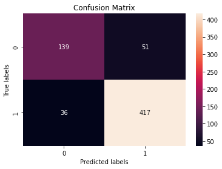

```python
cm=confusion_matrix(y_test_m, preddtc_m) #you will need to change the latter to your desired output
cm

ax= plt.subplot()
sns.heatmap(cm, annot=True, fmt='g', ax=ax);  #Don't worry too much about the arguments here - we will return to this!

# labels, title and ticks
ax.set_xlabel('Predicted labels');ax.set_ylabel('True labels');
ax.set_title('Confusion Matrix');
#ax.xaxis.set_ticklabels(['<=50K', '>50K']); ax.yaxis.set_ticklabels(['<=50K','>50K' ]);
TN, FP, FN, TP = confusion_matrix(y_test_m, preddtc_m).ravel()

print('True Positive(TP)  = ', TP)
print('False Positive(FP) = ', FP)
print('True Negative(TN)  = ', TN)
print('False Negative(FN) = ', FN)

print('Accuracy score :- {}'.format(round(accuracy_score(y_test_m, preddtc_m), 2)))
```

Running random forest classifier on train modified dataset and saved to a model